# Time Series Analysis

Katarzyna Gworek

# Project overview

This report analyses two monthly time series from January 2012 to December 2022. The first is the USD/PLN exchange rate, while the second describes greenhouse gas consumption in Italy. The analysis combines data visualization, decomposition, exponential smoothing and ARIMA/SARIMA forecasting.

This report presents the analysis of two monthly time series covering January 2012–December 2022.

The first series describes the USD/PLN exchange rate. The second describes greenhouse gas consumption in Italy. Both series were decomposed in JDemetra+ and subsequently analysed using extrapolation models and ARIMA/SARIMA models.

# 1. Non-seasonal time series – USD/PLN

## 1.1 Data preparation

The USD/PLN data are converted into a monthly time series. The last three observations are kept as an out-of-sample period for forecast evaluation.

```r
library(foreign)
library(xts)
library(urca)
library(lmtest)
library(fBasics)
library(forecast)
library(tseries)
library(fUnitRoots)

ASC_niesezonowe <- read.csv(
  "dane/Gworek_ASC_niesezonowe.csv",
  header = TRUE, sep = ";", dec = ","
)

ASC_niesezonowe.ts <- ts(
  ASC_niesezonowe$rate, start = c(2012, 1), frequency = 12
)

ASC_niesezonowe.in <- window(ASC_niesezonowe.ts, end = c(2022, 9))
ASC_niesezonowe.out <- window(ASC_niesezonowe.ts, start = c(2022, 10))
```

The training sample contains observations up to September 2022, while October–December 2022 are used to test forecast accuracy.

## 1.2 Visualization

The plot is used to assess the general behaviour of the exchange rate and to check for visible trend or seasonal patterns. The series does not show a clear seasonal pattern.

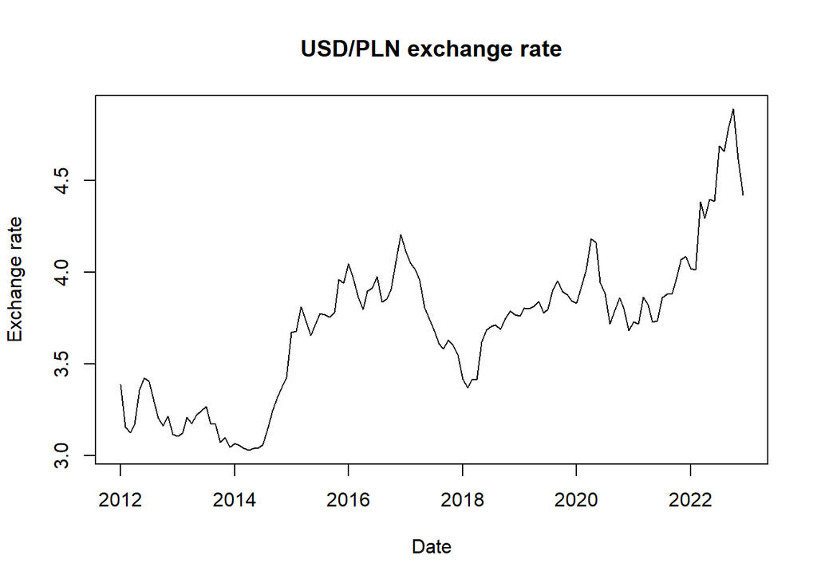

```r
plot(ASC_niesezonowe.ts,
     main = "USD/PLN exchange rate",
     xlab = "Date", ylab = "Exchange rate")
```

## 1.3 Exponential smoothing – EWMA

EWMA is used as a simple benchmark model without trend or seasonality. It provides a short-term forecast based mainly on the recent level of the series.

```r
EWMA <- HoltWinters(ASC_niesezonowe.in, beta = FALSE, gamma = FALSE)

EWMA.forecast <- predict(
  EWMA, n.ahead = 3, prediction.interval = TRUE
)
EWMA.forecast
```

```
##               fit      upr      lwr
## Oct 2022 4.787991 4.967758 4.608224
## Nov 2022 4.787991 5.042211 4.533771
## Dec 2022 4.787991 5.099341 4.476640
```

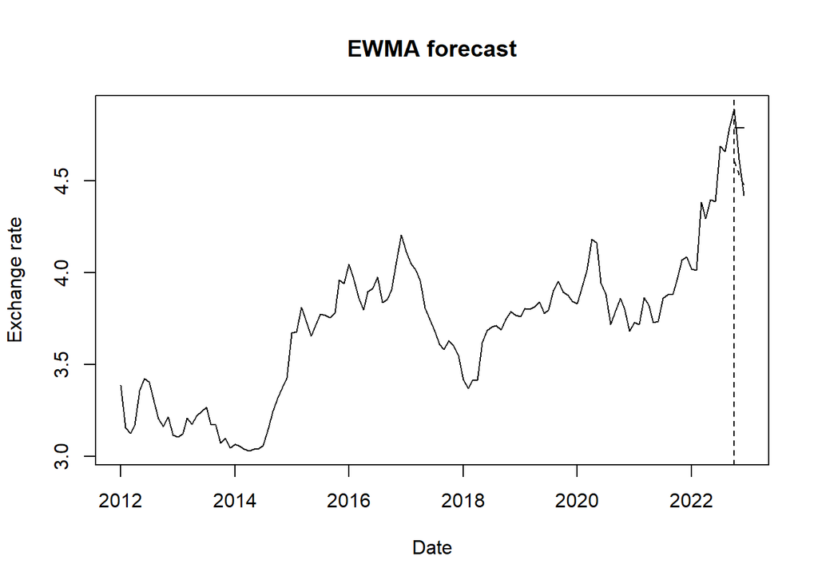

```r
plot(ASC_niesezonowe.ts, main = "EWMA forecast",
     xlab = "Date", ylab = "Exchange rate")
lines(EWMA.forecast[, 1])
lines(EWMA.forecast[, 2], lty = 2)
lines(EWMA.forecast[, 3], lty = 2)
abline(v = 2022 + 9/12, lty = 2)
```

## 1.4 Holt model

The Holt model extends exponential smoothing by allowing for a trend. It is therefore compared with EWMA because the exchange rate shows a general upward movement over the analysed period.

```r
Holt <- HoltWinters(ASC_niesezonowe.in, gamma = FALSE)

Holt.forecast <- predict(
  Holt, n.ahead = 3, prediction.interval = TRUE
)
Holt.forecast
```

```
##               fit      upr      lwr
## Oct 2022 4.874237 5.068106 4.680368
## Nov 2022 4.960474 5.267162 4.653785
## Dec 2022 5.046711 5.462944 4.630477
```

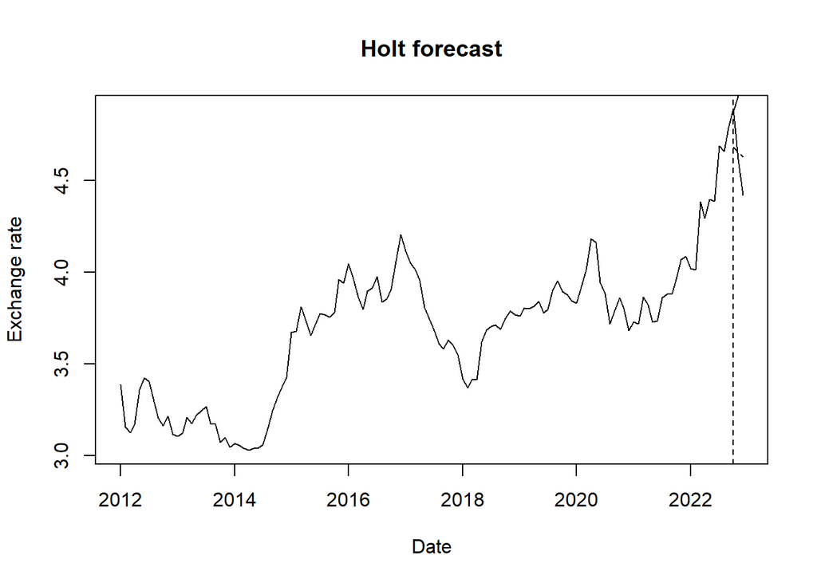

```r
plot(ASC_niesezonowe.ts, main = "Holt forecast",
     xlab = "Date", ylab = "Exchange rate")
lines(Holt.forecast[, 1])
lines(Holt.forecast[, 2], lty = 2)
lines(Holt.forecast[, 3], lty = 2)
abline(v = 2022 + 9/12, lty = 2)
```

## 1.5 ARIMA analysis

The first differences are examined to obtain a stationary series. ACF and PACF are then used to identify plausible AR and MA orders before comparing alternative ARIMA specifications.

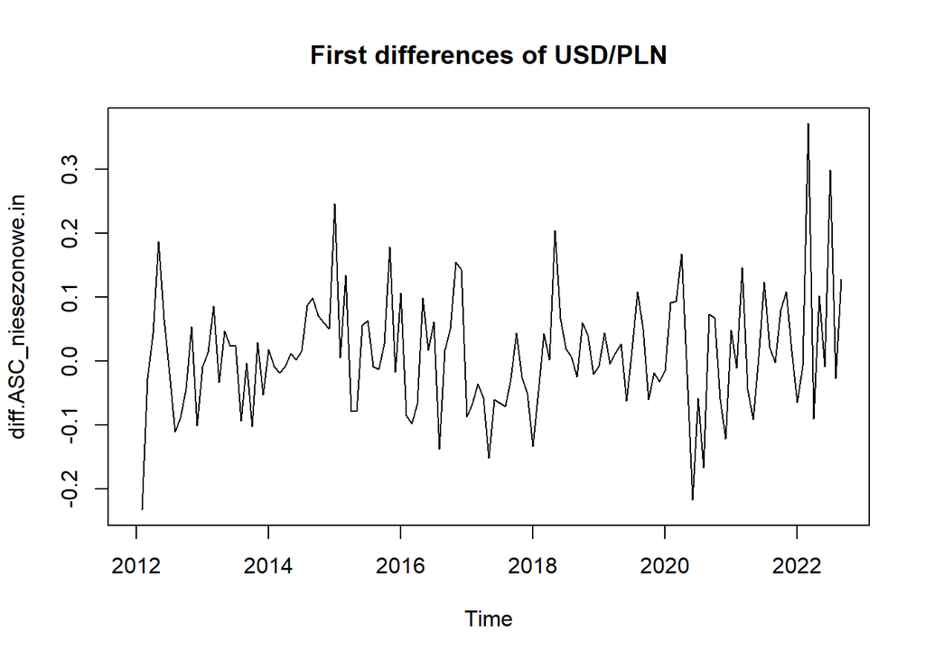

```r
diff.ASC_niesezonowe.in <- diff.xts(ASC_niesezonowe.in)

plot(diff.ASC_niesezonowe.in, type = "l",
     main = "First differences of USD/PLN")
```

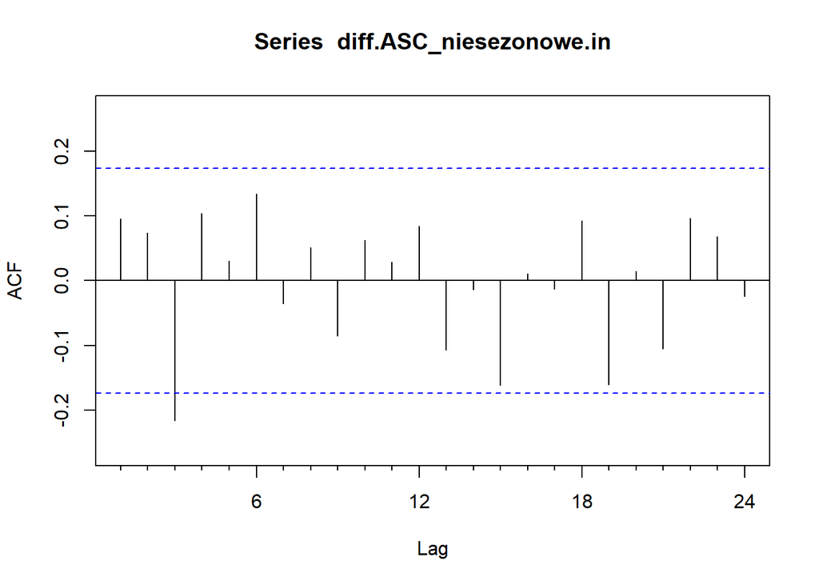

```r
Acf(diff.ASC_niesezonowe.in, lag.max = 24)
```

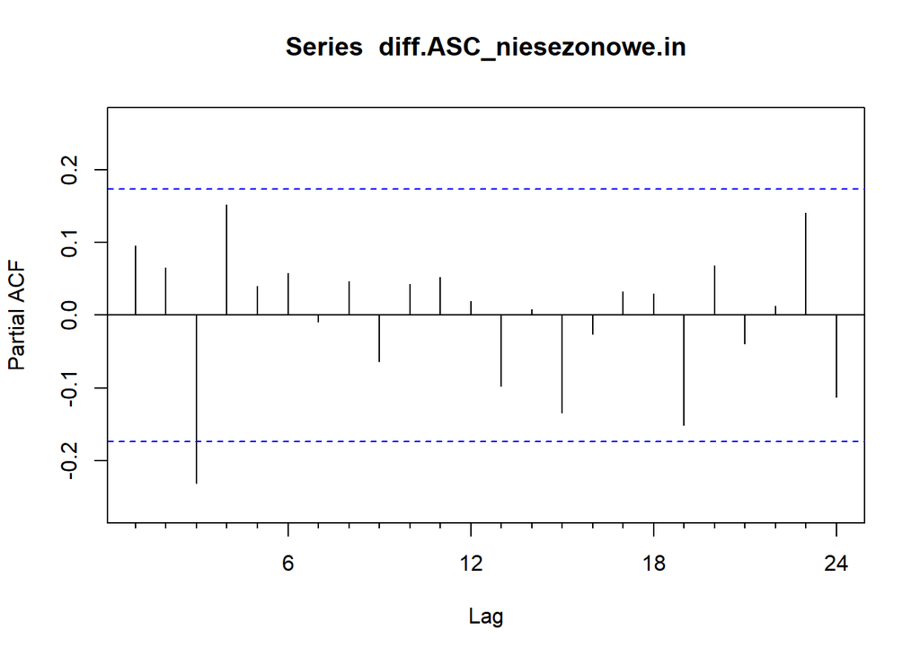

```r
Pacf(diff.ASC_niesezonowe.in, lag.max = 24)
```

```r
arima313 <- arima(diff.ASC_niesezonowe.in, order = c(3, 0, 3))
arima213 <- arima(diff.ASC_niesezonowe.in, order = c(2, 0, 3))
arima113 <- arima(diff.ASC_niesezonowe.in, order = c(1, 0, 3))
arima112 <- arima(diff.ASC_niesezonowe.in, order = c(1, 0, 2))

AIC(arima313); BIC(arima313)
```

```
## [1] -254.9485
```

```
## [1] -232.1323
```

```r
AIC(arima213); BIC(arima213)
```

```
## [1] -250.9406
```

```
## [1] -230.9763
```

```r
AIC(arima112); BIC(arima112)
```

```
## [1] -252.8609
```

```
## [1] -238.6007
```

## 1.6 Residual diagnostics

Residual ACF, PACF and Ljung–Box/Box–Pierce tests are used to check whether the selected ARIMA model has adequately captured the dependence in the data.

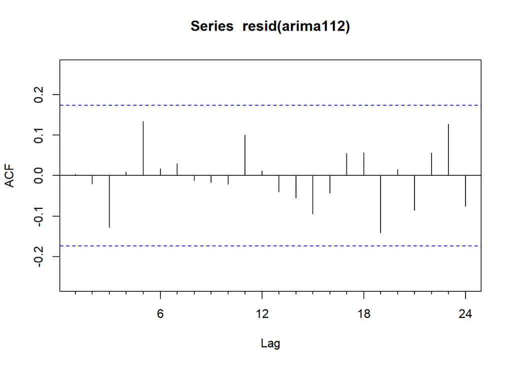

```r
Acf(resid(arima112), lag.max = 24)
```

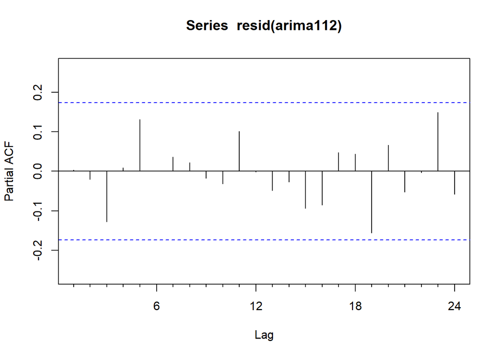

```r
Pacf(resid(arima112), lag.max = 24)
```

```r
Box.test(resid(arima112), type = "Ljung-Box", lag = 24)
```

```
##
##  Box-Ljung test
##
## data:  resid(arima112)
## X-squared = 17.74, df = 24, p-value = 0.8154
```

```r
Box.test(resid(arima112), type = "Box-Pierce", lag = 24)
```

```
##
##  Box-Pierce test
##
## data:  resid(arima112)
## X-squared = 15.464, df = 24, p-value = 0.9064
```

# 2. Seasonal time series – greenhouse gas consumption in Italy

The second series has a clear seasonal pattern: consumption is generally higher in winter and lower during spring and summer. This makes seasonal forecasting methods appropriate.

## 2.1 Data preparation

The Italian greenhouse gas consumption data are converted into a monthly time series. Twelve observations from 2022 are reserved as the out-of-sample period, representing one complete seasonal cycle.

```r
ASC_sezonowe <- read.csv(
  "dane/Gworek_ASC_sezonowe.csv",
  header = TRUE, sep = ";"
)

ASC_sezonowe.ts <- ts(
  ASC_sezonowe$Value, start = c(2012, 1), frequency = 12
)

sezonowy.in <- window(ASC_sezonowe.ts, end = c(2021, 12))
sezonowy.out <- window(ASC_sezonowe.ts, start = c(2022, 1))
```

A full year is reserved for testing so that the forecast evaluation covers all months of the seasonal cycle.

## 2.2 Visualization

The time-series plot is used to identify the main trend and recurring seasonal fluctuations. The visible annual pattern supports the use of seasonal models.

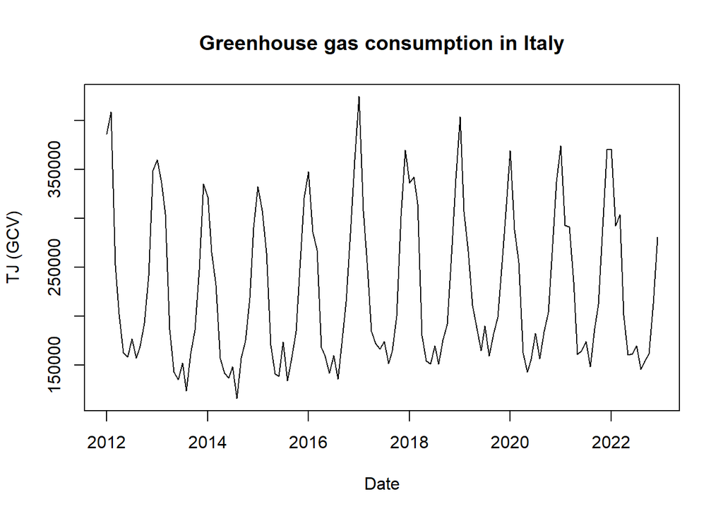

```r
plot(ASC_sezonowe.ts,
     main = "Greenhouse gas consumption in Italy",
     xlab = "Date", ylab = "TJ (GCV)")
```

## 2.3 Holt-Winters models

```r
sezonowy.HWadd <- HoltWinters(sezonowy.in, seasonal = "additive")
sezonowy.HWmult <- HoltWinters(sezonowy.in, seasonal = "multiplicative")

sezonowy.HWadd.forecast <- predict(
  sezonowy.HWadd, n.ahead = 12, prediction.interval = TRUE
)
sezonowy.HWmult.forecast <- predict(
  sezonowy.HWmult, n.ahead = 12, prediction.interval = TRUE
)

sezonowy.HWadd.forecast
```

```
##               fit      upr      lwr
## Jan 2022 389805.1 431842.1 347768.0
## Feb 2022 322504.9 365824.0 279185.8
## Mar 2022 298815.3 343436.0 254194.7
## Apr 2022 217445.5 263386.8 171504.3
## May 2022 180047.6 227328.2 132767.0
## Jun 2022 177952.6 226590.8 129314.4
## Jul 2022 196216.5 246230.2 146202.7
## Aug 2022 170539.7 221946.6 119132.9
## Sep 2022 199243.5 252060.7 146426.3
## Oct 2022 221439.3 275683.9 167194.8
## Nov 2022 289095.7 344784.3 233407.1
## Dec 2022 361990.0 419139.0 304840.9
```

```r
sezonowy.HWmult.forecast
```

```
##               fit      upr      lwr
## Jan 2022 400997.8 423480.5 378515.2
## Feb 2022 328308.4 353197.5 303419.3
## Mar 2022 303034.1 330408.4 275659.9
## Apr 2022 211932.4 238582.5 185282.3
## May 2022 171007.5 198431.3 143583.7
## Jun 2022 168060.0 198266.8 137853.1
## Jul 2022 186387.1 221384.6 151389.6
## Aug 2022 158155.0 192151.3 124158.8
## Sep 2022 188004.1 229018.6 146989.7
## Oct 2022 210728.4 257904.5 163552.2
## Nov 2022 280870.3 343490.3 218250.3
## Dec 2022 356291.5 432933.1 279649.9
```

## 2.4 Logarithmic transformation and differencing

The logarithm is used to reduce the scale of the series. Regular and seasonal differences are examined to obtain a stationary series suitable for SARIMA modelling.

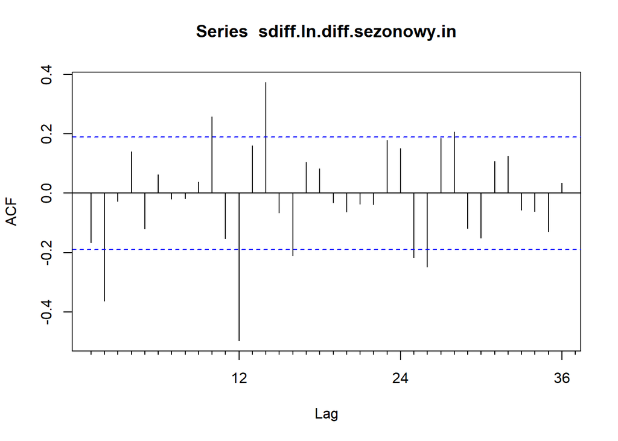

```r
ln.sezonowy <- log(ASC_sezonowe.ts)
ln.sezonowy.in <- window(ln.sezonowy, end = c(2021, 12))

ln.diff.sezonowy.in <- diff.xts(ln.sezonowy.in, lag = 1)
sdiff.ln.diff.sezonowy.in <- diff.xts(ln.diff.sezonowy.in, lag = 12)

Acf(sdiff.ln.diff.sezonowy.in, lag.max = 36)
```

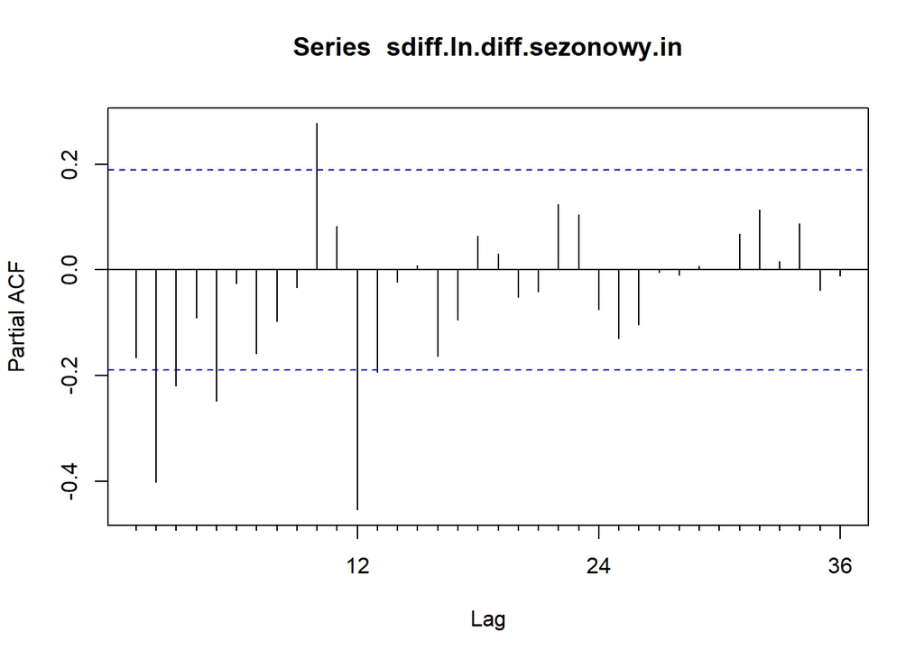

```r
Pacf(sdiff.ln.diff.sezonowy.in, lag.max = 36)
```

## 2.5 SARIMA models

SARIMA models account for both non-seasonal and seasonal dependence. Alternative specifications are compared using information criteria and model diagnostics.

```r
nobs <- length(ln.sezonowy.in)

arima010111 <- arima(
  ln.sezonowy.in,
  order = c(0, 1, 0),
  seasonal = list(order = c(1, 1, 1), period = 12),
  xreg = 1:nobs
)

arima010011 <- arima(
  ln.sezonowy.in,
  order = c(0, 1, 0),
  seasonal = list(order = c(0, 1, 1), period = 12),
  xreg = 1:nobs
)

AIC(arima010111); BIC(arima010111)
```

```
## [1] -188.138
```

```
## [1] -177.4467
```

```r
AIC(arima010011); BIC(arima010011)
```

```
## [1] -185.7576
```

```
## [1] -177.7391
```